# Optimizing the Flow of Traffic in Smart Cities through Network Analysis: A Comprehensive Strategy to Reduce Congestion and Enhance Urban Mobility

# 3- Proposed Methods

Network analysis, predictive modeling, and optimization strategies in the fight against the woes of traffic congestion for optimal urban mobility. Data collection will be the initial step, which will include detailed road network structures from OpenStreetMap and real-time traffic data by the use of IoT devices and sensors. In its stead would be a rich data acquisition to allow more judicious analysis of the road network in pointing out critical nodes and bottlenecks. Centrality, betweenness, and other key metrics will be used to locate the points at which there shall be maximum impact on traffic flow.

Predictive modeling will be developed using machine learning algorithms that will predict the conditions of the traffic with historical and current data. It has been supported by RBF networks and Gated Recurrent Units techniques for developing a traffic prediction model with a high accuracy rating. Adaptive traffic signal systems in the models will aid in future dynamic terms, adjusting with respect to signal timings according to the condition of real-time traffic. It will also provide rerouting strategies for traffic at peak hours, averting congestions based on insights learned through network analysis and predictive modeling.

The proposed methods herein also focus on integrating AI and IoT technologies in achieving better traffic management. Advanced analytics, real-time data, and attempts to find sustainable traffic management practices assure efficiency and resilience within urban transportation networks. That would be possible through continuous monitoring for adaptation to ensure the solutions remain effective over time.

The Dataset contains following tables and top 5 rows that came out during preprocessing are:

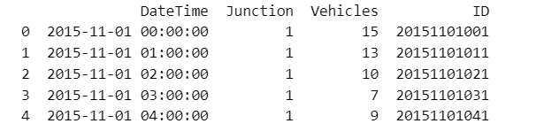

Fig: Top data rows of the dataset

For handling the missing values we dropped the row where the missing values were present so to ensure that data is consistent throughout.

# 4- Results

The following graph were obtained when analyzing the Dataset:

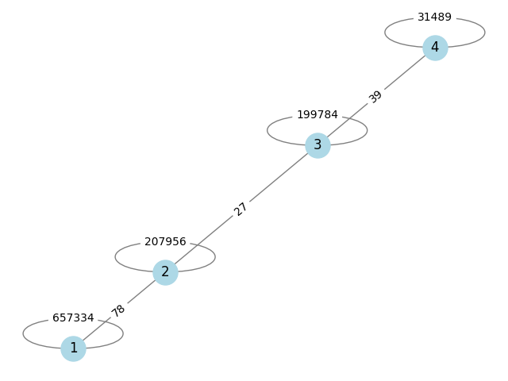

Graph of the traffic node analysis

The graph to be returned, based on the given code, will simply model traffic flow between junctions. The junctions themselves are represented by nodes, whereas the edges represent the flow of vehicles between those junctions. The weights on the edges reflect the number of vehicles moving between one junction and the next, providing quantitative measure for the traffic flow on each path.

The spring layout, minimization of crossings, and spreading the nodes as much as possible in space are all part of an idea that enhances readability of the graph. Beyond that, all nodes are colored light blue for better distinction, edges are gray-colored in order to represent the relations between nodes, and the edge labels show weights so that one can get at-a-glance knowledge about the magnitude of the traffic on each link.

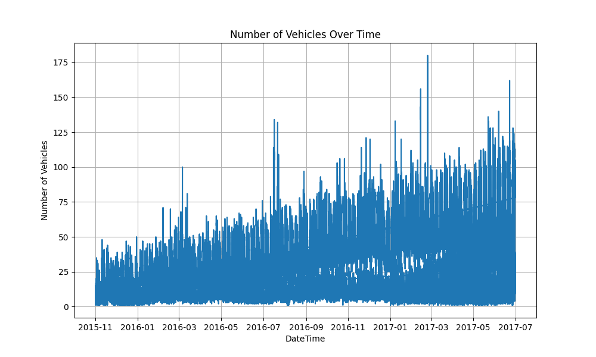

Fig: Time series plot

A plot displays vehicle counts according to time. This diagram presents how traffic volume alters over a passage of time and captures the wavering number of cars within this same duration. The x-axis represents the timeline while y-axis is used for the number of vehicles seen.

There are several interesting trends indicated by these plotted points. At some point, most space in an area may be occupied by motor vehicles due to either peak hours or an event taking place while others have few cars passing it. Based on this difference, it is possible to determine changes in traffic that depict alteration in flow from one period to another.

Some important things can be noted from this time series graph: Peak Periods: Counts reaching their highest points may correspond with rush hours/commuting times, major events or holidays.

As far as traffic management is concerned, this analysis helps identify crucial periods when congestion may occur necessitating measures to enhance flow and decrease congestion.

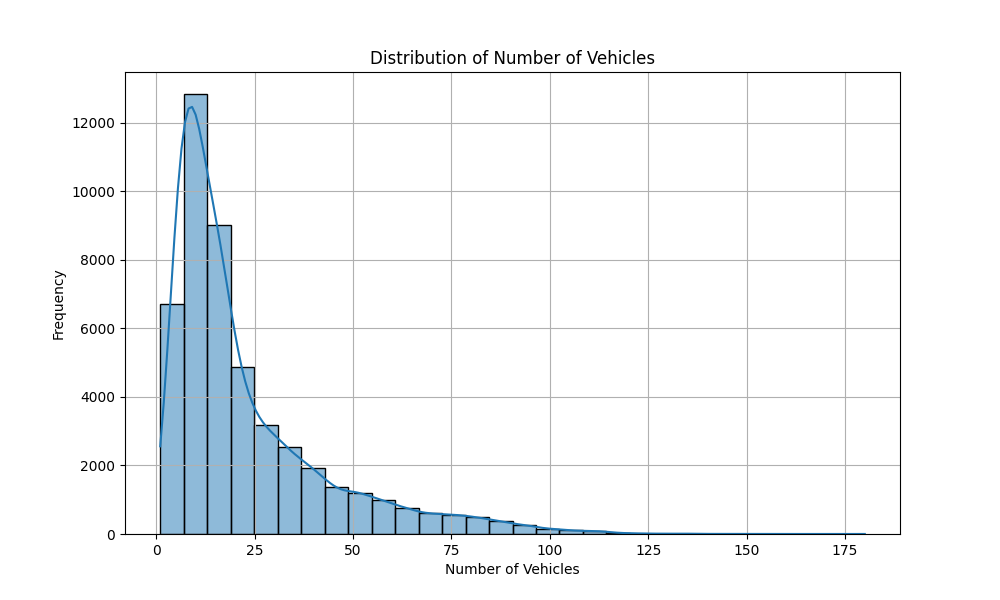

Fig: Distribution of the Number of Vehicles

In the histogram, bins represent the number of vehicles on the x-axis while frequencies are represented on the y-axis. By viewing this chart, it is easy to understand how many cars are distributed in a given dataset.

Main findings from the talk include: • Shape of distribution: The shape of distributions may indicate whether data is normally distributed or skewed.

• Peaks in frequency: It is possible to determine typical traffic volumes by locating peaks on histograms.

• Outliers: There might be peculiar traffic conditions or anomalies if there are significant deviations from central distribution.

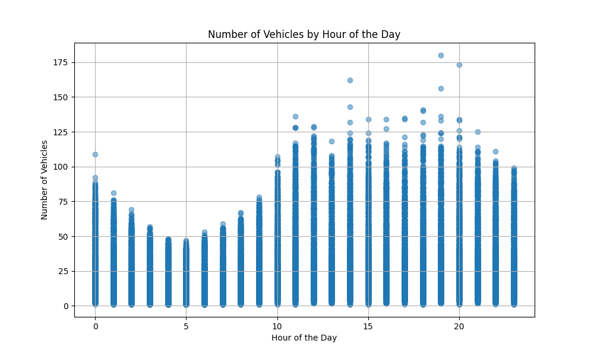

Fig: Number of Vehicles by Hour of the Day

This figure shows a scatter plot of the number of vehicles in relation to time of day. On the x-axis, there is the hour while on y-axis, it is the number of cars that have been counted. Each point on this scatter plot stands for how many vehicles were at different times. Major things that can be learnt from studying this scatter plot are: • Traffic Peaks and Troughs: This identifies specific hours at which vehicle counts are higher or lower and can be associated with peak and off-peak traffic periods. • Patterns or Clusters: It shows if any patterns or clusters point towards a uniform traffic flow during some hours. • Anomalies: Intrinsic characteristics of the data set such as deviation from the mean.

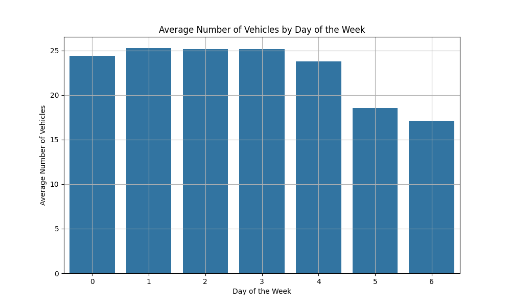

Fig: Average Number of Vehicles by Day of the Week

This figure above presents the average vehicle number for each day of the week in a bar graph. The days of the week are represented along the x-axis while the average vehicle counts are shown on y-axis. Important results from this bar graph are: • Daily Traffic Patterns: This section underlines differences in mean car numbers between different weekdays and weekends, which may signify different traffic tendencies thereon. • Highest and Lowest Averages: It also shows most and fewest vehicles during particular days to help planners see what is happening daily when it comes to traffic issues. • Weekly Trends: This diagram also discovers any weekly patterns or exceptions that could impact on traffic planning and control.

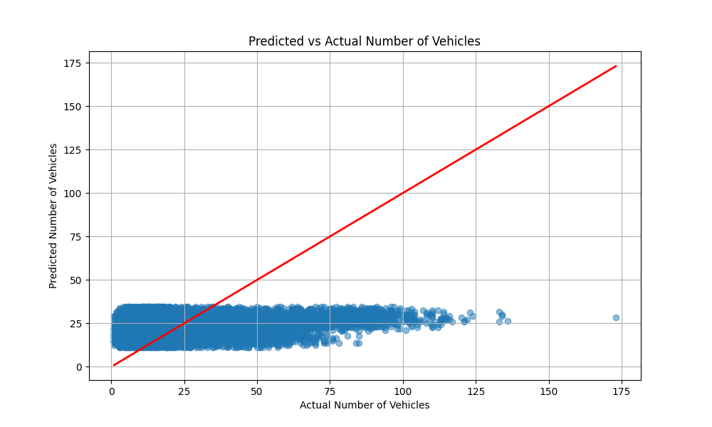

Fig: Predicted vs Actual Number of Vehicles

This figure compares the anticipated vehicle numbers and actual counts. The x-axis represents the number of vehicles actually counted, while the y-axis shows expected numbers. Each point on the plot corresponds to a pair of observed and predicted values. Major takeaways from this graph are as follows:

• Prediction Accuracy: Estimation of how well the model predicts what is true in terms of vehicle quantities. • Correlation: The accuracy of a model increases when its predictions lie near those that would be given by real world situations. • Discrepancies: Points far away from the red line which represents perfect predictions (red line) show areas where there might be need for improvement in the model itself.

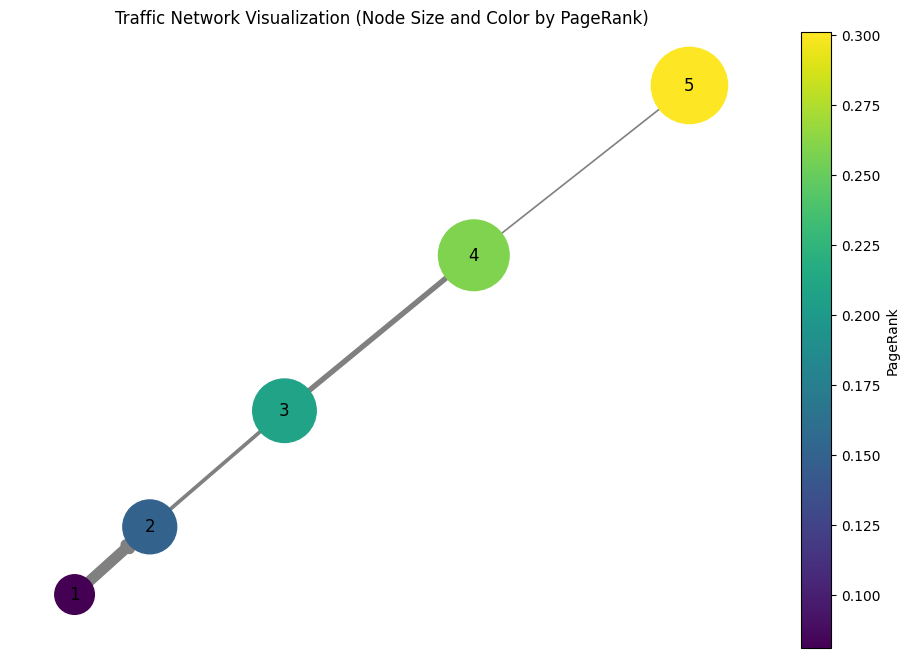

Fig: Traffic Network Visualization (Node Size and Color by PageRank)

• Efficient Hubs: These are nodes with higher values of PageRank; for instance, nodes 4 and 3 help bring about efficiency in the movement of traffic within the network. These form the strategically vital nodes that help in keeping the flow of traffic steady.

• Optimization of Traffic: The overall efficiency of the traffic network can be greatly enhanced by targeting nodes with high PageRank for traffic signal optimization and rerouting strategies. Upgrading traffic signals at nodes, for example, 5 may have the advantage of increasing traffic flow for the entire network.

• Balance and Connectivity: The balance and connectivity for the network are indicated by the distribution of PageRank. Nodes 1 and 2, with less significant PageRank values, are still important to hold the network together.

# 5- Discussion

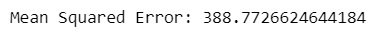

Fig: Mean Squared Error of the machine learning model

It contributes an MSE of 388.77, which states how well a model fits the data in the case of regression tasks. MSE is a measure of the average of the squares of the errors. The lower the MSE value, the better the predictive accuracy of the model; the higher it is, the more the predicted deviates from the real value.

For the traffic prediction, this MSE is likely to come from, providing an important metric that will tell how well the model foresees traffic flow or vehicle counts at junctions. An MSE of 388.77 is a pointer to the degree of error in the predictions generated by this model. How big this error is informs about the ability of the model to capture the underlying patterns in the traffic data. This mean-squared error for the estimate may be driven by many different factors in a traffic prediction model. Among the largest was the model complexity and quality itself. For instance, probably with the use of a more complex model, likely to be of machine learning algorithms using decision trees, random forests, or neural networks, one may strive to reduce the MSE by capturing some nonlinear relationship in the data. There is also the risk of overfitting: it works perfectly on training data and poorly on unseen data. The quality of the data is another critical element impacting MSE. Inaccuracies within the traffic dataset in the form of missing values, outliers, or noise increase the amount of error. Proper data preprocessing that includes the handling of missing values, removal of outliers, and normalization can be done to decrease the MSE.

Feature selection and engineering are therefore the keys to the performance of the model. Proper choice of relevant features that truly affect the traffic patterns, and feature engineering of new features that capture these very hidden relationships, can bring a high impact on the MSE.

Basically, what is sought in the application is the minimization of the MSE while at the same time keeping the model generalizable to new data. Most of the time, bias and variance are traded against each other; any model needs to find a middle way in order to obtain a low prediction error. With metrics such as MSE, continuous evaluation will be important in refining models for better predictive capabilities, hence efficient traffic management and planning.

# 6- Conclusion

The implications of this research extend to urban planning and policy-making. Data-driven approaches to traffic optimization provide valuable insights for designing more effective, sustainable, and resilient transportation networks. Urban planners can leverage these insights to invest in adaptive traffic signal systems, strategic rerouting measures, and public transportation infrastructure. Aligning these investments with real-time data and predictive models can significantly improve traffic flow, reduce congestion, and enhance the quality of life for residents through decreased travel times and improved air quality.

Policymakers play a crucial role in facilitating the implementation of traffic optimization strategies by fostering an environment conducive to innovation and technology adoption. Policies that encourage public-private partnerships, promote public transportation, and support the integration of emerging technologies are essential for the successful implementation of these solutions.

# References

1. Hsu, H.-C., & Chiu, M.-L. (2013). Optimization of urban road traffic in intelligent transport systems. Journal of Applied Mathematics. https://onlinelibrary.wiley.com/doi/10.1155/2013/7 06919
2. Amoretti, M., & La Cava, G. (2023). Traffic flow optimization strategies in smart cities. WSEAS Transactions on Systems and Control, 18. https://wseas.com/journals/sac/2023/a385103- 009(2023).pdf
3. Hsu, H.-C. (2013). Optimization of urban road traffic in intelligent transport systems. ResearchGate. https://www.researchgate.net/publication/26142866 5_Optimization_of_urban_road_traffic_in_Intellige nt_Transport_Systems
4. Pappalardo, L., & Pivato, M. (2023). Urban traffic flow optimization using real-time data. Sustainability, 15(7), 5949. https://www.mdpi.com/2071-1050/15/7/5949
5. Rizzo, D., & Marullo, S. (2023). Data-driven approaches to traffic management in smart cities. Sustainability, 15(19), 14441. https://www.mdpi.com/2071-1050/15/19/14441
6. Xu, Y., & Zhang, J. (2020). Analyzing traffic congestion patterns using machine learning. Sustainability, 12(6), 2291.
7. https://www.mdpi.com/2071-1050/12/6/2291 Chen, T., & Zhang, X. (2015). Predicting urban traffic congestion using network analysis. Semantic Scholar. https://www.semanticscholar.org/reader/73906458a 7e6459c2420e01cc0e95e780b239ecc
8. Wischik, D., & Zhao, J. (2004). Optimizing traffic flow with data-driven approaches. ACM SIGCOMM Computer Communication Review. https://sites.cc.gatech.edu/classes/AY2007/cs7260_ spring/papers/odflows-sigm04.pdf
9. Li, S., & Liu, W. (2015). Advanced traffic flow optimization techniques. arXiv preprint. https://arxiv.org/abs/1507.05722